# Filtering of chromatographic peaks in an XCMS object

Kristian Pirttilä

2021-10-25

# Introduction

This tutorial describes the CPC package functionality on an example data set included with the package. We will load the example dataset, perform peak picking using XCMS and apply the CPC algorithm to filter the peaks detected. Furthermore, we will showcase the data extraction methods and visualize the results.

# Setup environment

```r
library(xcms)
library(cpc)
library(ggvenn)
```

# XCMS processing

The first step in this tutorial is to use XCMS to process the reduced data set. This step normally takes a long time to run on a full dataset, however, thanks to the significant filtering made, it should run very fast on an average desktop PC. For more information on how to use XCMS for processing LC/MS data, see XCMS documentation. Only the peak picking will be performed as the retention alignment will not work properly with this heavily filtered dataset, and is not important to illustrate the workflow.

```r
# get example raw data file paths from package
fp_raw <- list.files(system.file("extdata", package = "cpc"), full.names = T)

# setup multi-core processing for XCMS
register(bpstart(SnowParam()))

# setup metadata
(pd <- data.frame(sample_name = paste0("HILIC_", seq(1,4,1)),
                  sample_group = rep("HILIC_POS", 4),
                  stringsAsFactors = F))
```

```
#>   sample_name sample_group
#> 1     HILIC_1    HILIC_POS
#> 2     HILIC_2    HILIC_POS
#> 3     HILIC_3    HILIC_POS
#> 4     HILIC_4    HILIC_POS
```

```r
# Create raw data object
(msraw <- MSnbase::readMSData(files = fp_raw,
                              pdata = new("NAnnotatedDataFrame", pd),
                              mode = "onDisk", msLevel. = 1, centroided. = T))
```

```
#> MSn experiment data ("OnDiskMSnExp")
#> Object size in memory: 1.54 Mb
#> - - - Spectra data - - -
#>  MS level(s): 1
#>  Number of spectra: 5200
#>  MSn retention times: 0:02 - 11:18 minutes
#> - - - Processing information - - -
#> Data loaded [Wed Jan 12 14:39:00 2022]
#> Filter: select MS level(s) 1. [Wed Jan 12 14:39:00 2022]
#>  MSnbase version: 2.18.0
#> - - - Meta data  - - -
#> phenoData
#>   rowNames: 1 2 3 4
#>   varLabels: sample_name sample_group
#>   varMetadata: labelDescription
#> Loaded from:
#>   [1] hilic015.mzML...  [4] hilic021.mzML
#>   Use 'fileNames(.)' to see all files.
#> protocolData: none
#> featureData
#>   featureNames: F1.S0001 F1.S0002 ... F4.S1300 (5200 total)
#>   fvarLabels: fileIdx spIdx ... spectrum (35 total)
#>   fvarMetadata: labelDescription
#> experimentData: use 'experimentData(object)'
```

```r
# --- PEAK DETECTION ---

# run peak detection
xd <- xcms::findChromPeaks(msraw,
                           param = xcms::CentWaveParam(ppm = 60,
                                                       peakwidth = c(5, 50),
                                                       fitgauss = T,
                                                       noise = 200,
                                                       integrate = 2,
                                                       prefilter = c(5, 1000),
                                                       verboseColumns = T,
                                                       mzdiff = 0.01),
                           msLevel = 1L)
```

[output not shown]

[output cut: 9 more lines]

[output not shown]

```r
print(xd)
```

```
#> MSn experiment data ("XCMSnExp")
#> Object size in memory: 1.54 Mb
#> - - - Spectra data - - -
#>  MS level(s): 1
#>  Number of spectra: 5200
#>  MSn retention times: 0:02 - 11:18 minutes
#> - - - Processing information - - -
#> Data loaded [Wed Jan 12 14:39:00 2022]
#> Filter: select MS level(s) 1. [Wed Jan 12 14:39:00 2022]
#>  MSnbase version: 2.18.0
#> - - - Meta data  - - -
#> phenoData
#>   rowNames: 1 2 3 4
#>   varLabels: sample_name sample_group
#>   varMetadata: labelDescription
#> Loaded from:
#>   [1] hilic015.mzML...  [4] hilic021.mzML
#>   Use 'fileNames(.)' to see all files.
#> protocolData: none
#> featureData
#>   featureNames: F1.S0001 F1.S0002 ... F4.S1300 (5200 total)
#>   fvarLabels: fileIdx spIdx ... spectrum (35 total)
#>   fvarMetadata: labelDescription
#> experimentData: use 'experimentData(object)'
#> - - - xcms preprocessing - - -
#> Chromatographic peak detection:
#>  method: centWave
#>  1110 peaks identified in 4 samples.
#>  On average 278 chromatographic peaks per sample.
```

# CPC peak filtering

The way in which the CPC package is applied to the workflow is via two wrapper functions, *characterize_peaklist()* and *filter_xcms_peaklist()*. The first one will only characterize the peaks detected by XCMS and returns a *cpc* object, whereas the second will call *characterize_peaklist()* as well as run the filtering method and can return either a *cpc* object containing all the information, including the filtered XCMSnExp object, or only the filtered XCMSnExp object. For incorporating the package into an XCMS workflow, it is recommended to use the function *filter_xcms_peaklist()* with *return_type = “xcms”* or use the *getFilteredXCMS()* method on the *cpc* object returned by *filter_xcms_peaklist()* as both cases will give the same result. The latter case will be used in this tutorial as we want to keep the information contained in the *cpc* object.

The *cpcProcParam* object holds processing parameters for both peak characterization as well as peak filtering.

```r
cpc <- cpc::filter_xcms_peaklist(xd = xd, return_type = "cpc",
                                 param = cpc::cpcProcParam(min_sn = 10,
                                                           min_pts = 10,
                                                           min_intensity = 2000))
```

```
#> Processing file: C:\Users\kripi733\AppData\Local\Temp\RtmpusE9Et\temp_libpath39001f3d545d\cpc\extdata\hilic015.mzML
#> Found 268 peak(s).
#> % complete:
#> 0
#> 10
#> 20
#> 30
#> 40
#> 50
#> 60
#> 70
#> 80
#> 90
#> 100
#> Done!
#> Finished in 4.535 secs.
#> Processing file: C:\Users\kripi733\AppData\Local\Temp\RtmpusE9Et\temp_libpath39001f3d545d\cpc\extdata\hilic017.mzML
#> Found 296 peak(s).
#> % complete:
#> 0
#> 10
#> 20
#> 30
#> 40
#> 50
#> 60
#> 70
#> 80
#> 90
#> 100
#> Done!
#> Finished in 5.511 secs.
#> Processing file: C:\Users\kripi733\AppData\Local\Temp\RtmpusE9Et\temp_libpath39001f3d545d\cpc\extdata\hilic019.mzML
#> Found 264 peak(s).
#> % complete:
#> 0
#> 10
#> 20
#> 30
#> 40
```

[output cut: 10 more lines]

```
#> % complete:
#> 0
#> 10
#> 20
#> 30
#> 40
#> 50
#> 60
#> 70
#> 80
#> 90
#> 100
#> Done!
#> Finished in 3.874 secs.
#> Keeping 923 of 1110 (83.15%) peaks.
```

Processing times will depend heavily on the computer hardware used. With this data set the processing times are very fast (<10 seconds per file), but that is due to the heavy filtering that has been done. More realistic processing times, when working with full LC/MS data sets, range from a 2-10 minutes per file, scaling linearly with the number of peaks detected by XCMS.

After processing we can get the original peak table from the XCMS object and the characterized peak table from the CPC object using the methods *cpt* and *getPeaklist*.

```r
cpcPeaktable <- cpc::cpt(cpc)
```

The peak table that you get from the CPC package has a number of determined peak characteristics as well as calculated peak characteristics.

| Column | Description |
| --- | --- |
| id | The row number of the peak in the original peak table from XCMS. |
| rt | Peak retention time in seconds. |
| rtmin | Peak front bound in seconds. |
| rtmax | Peak tail bound in seconds. |
| rtf1b | Peak front bound at 1% peak height. |
| rtt1b | Peak tail bound at 1% peak height. |
| rtf5b | Peak front bound at 5% peak height. |
| rtt5b | Peak tail bound at 5% peak height. |
| rtf10b | Peak front bound at 10% peak height. |
| rtt10b | Peak tail bound at 10% peak height. |
| rtf50b | Peak front bound at 50% peak height. |
| rtt50b | Peak tail bound at 50% peak height. |
| apex | The most intense scan point in the peak. |
| finf | The interpolated front inflection point of the peak where the second derivative crosses zero. |
| tinf | The interpolated tail inflection point of the peak where the second derivative crosses zero. |
| fblb | The determined front baseline boundary scan. |
| tblb | The determined tail baseline boundary scan. |
| fpkb | The determined front peak bound. |
| tpkb | The determined tail peak bound. |
| fcode | The front peak bound type (B = baseline, V = valley, S = shoulder, R = rounded peak). |
| tcode | The tail peak bound type (B = baseline, V = valley, S = shoulder, R = rounded peak). |
| blslp | The slope of the baseline calculated between fblb and tblb. |
| emu | The mu value of the fitted exponentially modified gaussian (EMG) function. This is only calculated if EMG deconvolution is turned on. |
| esigma | The sigma value of the fitted EMG function. This is only calculated if EMG deconvolution is turned on. |
| elambda | The lambda value of the fitted EMG function. This is only calculated if EMG deconvolution is turned on. |
| earea | The area modifier of the fitted EMG function. This is only calculated if EMG deconvolution is turned on. |
| econv | An indicator if the Nelder-Mead minimizer converged when performing EMG deconvolution. |
| note | A character statement describing the result of the peak processing. This can be “detected”, “not_detected”, “too_narrow”, “low_sn”, “too_small”. |
| height | The peak height calculated between the apex scan point and the interpolated baseline value at that point. |
| fh1b | Front bound at 1% peak height. |
| th1b | Tail bound at 1% peak height. |
| fh5b | Front bound at 5% peak height. |
| th5b | Tail bound at 5% peak height. |
| fh50b | Front bound at 50% peak height. |
| th50b | Tail bound at 50% peak height. |
| wb | Base width of the peak calculated as th5b-fh5b. |
| fwhm | Full width at half maxima of the peak calculated as th50b-fh50b. |
| area | The area of the peak calculated using a trapezoid integrator between fh1b and th1b. |
| a | *apex* - *fpkb*. Used to calculate the tailing factor. |
| b | *tpkb* - *apex*. Used to calculate the tailing factor. |
| tf | The tailing factor calculated as *tf* = *b*/*a*. |
| sn | The calculated signal-to-noise ratio calculated as *sn* = 2**height*/noise. |
| file | Which sample file the peak was detected in. |
| exectime | The execution time for the peak in seconds. |

# Visualizing the results

```r
# get the original xcms object using getOriginalXCMS()
xdOrig <- cpc::getOriginalXCMS(cpc)

xdOrig
```

```
#> MSn experiment data ("XCMSnExp")
#> Object size in memory: 1.54 Mb
#> - - - Spectra data - - -
#>  MS level(s): 1
#>  Number of spectra: 5200
#>  MSn retention times: 0:02 - 11:18 minutes
#> - - - Processing information - - -
#> Data loaded [Wed Jan 12 14:39:00 2022]
#> Filter: select MS level(s) 1. [Wed Jan 12 14:39:00 2022]
#>  MSnbase version: 2.18.0
#> - - - Meta data  - - -
#> phenoData
#>   rowNames: 1 2 3 4
#>   varLabels: sample_name sample_group
#>   varMetadata: labelDescription
#> Loaded from:
#>   [1] hilic015.mzML...  [4] hilic021.mzML
#>   Use 'fileNames(.)' to see all files.
#> protocolData: none
#> featureData
#>   featureNames: F1.S0001 F1.S0002 ... F4.S1300 (5200 total)
#>   fvarLabels: fileIdx spIdx ... spectrum (35 total)
#>   fvarMetadata: labelDescription
#> experimentData: use 'experimentData(object)'
#> - - - xcms preprocessing - - -
#> Chromatographic peak detection:
#>  method: centWave
#>  1110 peaks identified in 4 samples.
#>  On average 278 chromatographic peaks per sample.
```

```r
# get the original peak table
xcmsPeaktableOrig <- data.frame(xcms::chromPeaks(xdOrig))

# get the filtered xcms object using getFilteredXCMS()
xdFilt <- cpc::getFilteredXCMS(cpc)

xdFilt
```

```
#> MSn experiment data ("XCMSnExp")
#> Object size in memory: 1.54 Mb
#> - - - Spectra data - - -
#>  MS level(s): 1
#>  Number of spectra: 5200
#>  MSn retention times: 0:02 - 11:18 minutes
#> - - - Processing information - - -
#> Data loaded [Wed Jan 12 14:39:00 2022]
#> Filter: select MS level(s) 1. [Wed Jan 12 14:39:00 2022]
#>  MSnbase version: 2.18.0
#> - - - Meta data  - - -
#> phenoData
#>   rowNames: 1 2 3 4
#>   varLabels: sample_name sample_group
#>   varMetadata: labelDescription
#> Loaded from:
#>   [1] hilic015.mzML...  [4] hilic021.mzML
#>   Use 'fileNames(.)' to see all files.
#> protocolData: none
#> featureData
#>   featureNames: F1.S0001 F1.S0002 ... F4.S1300 (5200 total)
#>   fvarLabels: fileIdx spIdx ... spectrum (35 total)
#>   fvarMetadata: labelDescription
#> experimentData: use 'experimentData(object)'
#> - - - xcms preprocessing - - -
#> Chromatographic peak detection:
#>  method: centWave
#>  923 peaks identified in 4 samples.
#>  On average 231 chromatographic peaks per sample.
```

```r
# get the filtered peak table
xcmsPeaktableFilt <- data.frame(xcms::chromPeaks(xdFilt))

# get the filtered cpc peak table
cpcPeaktableFilt <- cpcPeaktable[row.names(xcmsPeaktableFilt), ]
```

To see how many peaks were removed in a file-by-file basis you can use the table function on the chromatographic peak table from the xcms object.

```r
rbind(Original = table(xcmsPeaktableOrig[, "sample"]),
      Filtered = table(xcmsPeaktableFilt[, "sample"]),
      PercentKept = round(100*table(xcms::chromPeaks(xdFilt)[, "sample"]) /
        table(xcms::chromPeaks(xdOrig)[, "sample"]), 1))
```

```
#>                 1     2     3     4
#> Original    268.0 296.0 264.0 282.0
#> Filtered    226.0 238.0 221.0 238.0
#> PercentKept  84.3  80.4  83.7  84.4
```

The filtering outcomes can be extracted from the object using the *getFilterOutcomes()* method. This returns a data.frame indicating if a peak passed the filter criteria or not for the different filter characteristics.

```r
outcomes <- cpc::getFilterOutcomes(cpc)

head(outcomes)
```

```
#>        detected    sn width fwhm   tf intensity
#> CP0001     TRUE FALSE FALSE TRUE TRUE      TRUE
#> CP0002     TRUE  TRUE  TRUE TRUE TRUE      TRUE
#> CP0003     TRUE  TRUE  TRUE TRUE TRUE      TRUE
#> CP0004     TRUE  TRUE  TRUE TRUE TRUE      TRUE
#> CP0005     TRUE  TRUE  TRUE TRUE TRUE      TRUE
#> CP0006     TRUE  TRUE  TRUE TRUE TRUE      TRUE
```

To check which peaks are retained and which are removed, the outcomes data.frame can be used. A character vector of removed and retained peak IDs can also be obtained using the *getRemovedPeaks()* and *getRetainedPeaks()* methods, respectively. We can visualize the filtering outcomes using a Venn diagram.

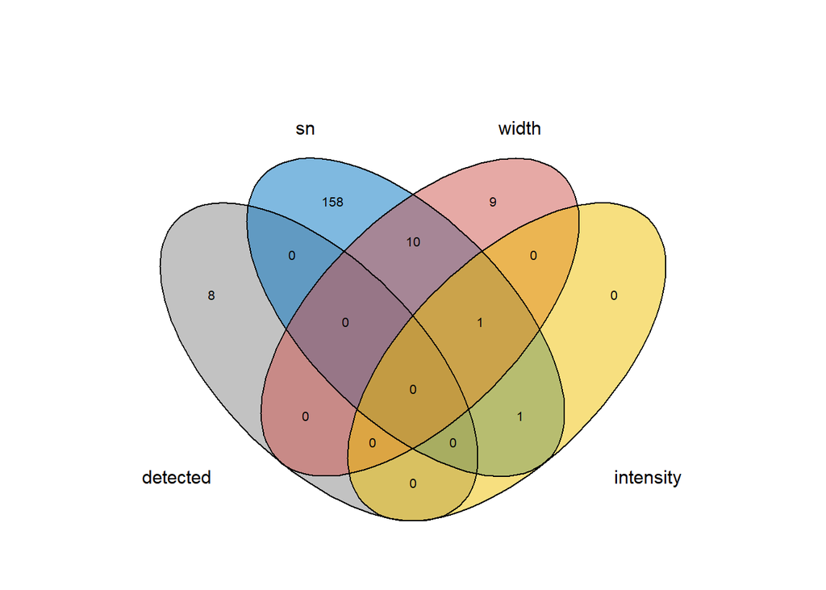

```r
# setup a list for the Venn diagram
outcomesList <- lapply(outcomes, function(x) which(!x))

# output a Venn diagram for the used filters
ggvenn::ggvenn(data = outcomesList[c(1, 2, 3, 6)], show_percentage = FALSE,
               stroke_size = 0.5, set_name_size = 4, text_size = 2.8,
               fill_color = c("#868686FF", "#0073C2FF", "#CD534CFF",
                              "#EFC000FF", "#073b4cFF"))
```

We can see that 8 peaks were not detected at all, ie. did not exhibit the characteristic pattern in the second derivative. Apart from those, the majority of peaks were removed due to their signal-to-noise being too low (SN<10).

```r
# set a seed for sample() to make it reproducible
seed <- 12345

# as an example we will select 2 peaks from each filter outcome
# (1) Not detected as a peak,
# (2) Too low signal-to-noise,
# (3) Too low intensity (only 1 peak here)
# (4) Too narrow
set.seed(seed); randomRemoved <- list(
  nd = sample(which(apply(outcomes, 1, function(x) { # (1)
    return(!x[1] &
             x[2] &
             x[3] &
             x[4] &
             x[5] &
             x[6])
  })), 2),
  lowsn = sample(which(apply(outcomes, 1, function(x) { # (2)
    return(x[1] &
             !x[2] &
             x[3] &
             x[4] &
             x[5] &
             x[6])
  })), 2),
  lowint = which(apply(outcomes, 1, function(x) { # (3)
    return(x[1] &
             !x[2] &
             x[3] &
             x[4] &
             x[5] &
             !x[6])
  })),
  toonarrow = sample(which(apply(outcomes, 1, function(x) { # (4)
    return(x[1] &
             x[2] &
             !x[3] &
             x[4] &
             x[5] &
             x[6])
  })), 2)
)

randomRemoved
```

```
#> $nd
#> CP0661 CP0352
#>    661    352
#>
#> $lowsn
#> CP1033 CP0359
#>   1033    359
#>
#> $lowint
#> CP0245
#>    245
#>
#> $toonarrow
#> CP0906 CP0549
#>    906    549
```

And then we can plot these peaks using the *plotPeaks()* function. This function takes a *cpc* object as well as a list of peak IDs as argument. The peak IDs can be supplied as indices in the full peak list (ie. not the filtered peak list) or as a character vector with peak IDs (row names in the peak tables). In the present example they are the same and we can use either the names of randomRemoved or the values.

```
#> Opening file: C:\Users\kripi733\AppData\Local\Temp\RtmpusE9Et\temp_libpath39001f3d545d\cpc\extdata\hilic017.mzML
```

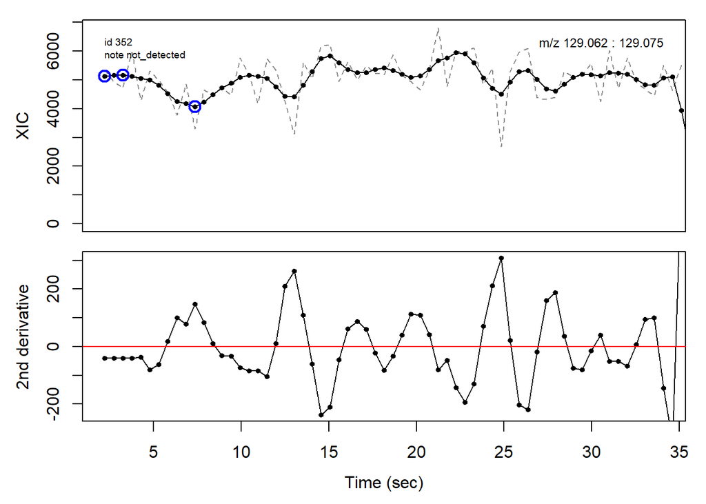

```
#> Opening file: C:\Users\kripi733\AppData\Local\Temp\RtmpusE9Et\temp_libpath39001f3d545d\cpc\extdata\hilic019.mzML
```

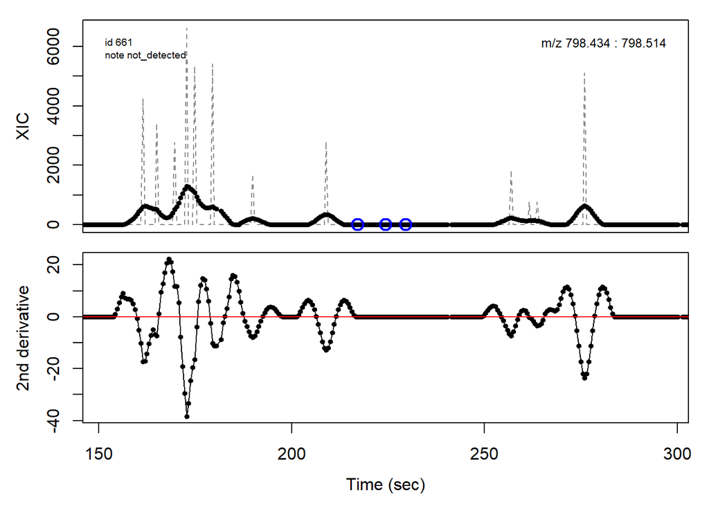

```r
cpc::plotPeaks(cpc, peakIdx = randomRemoved[[1]])
```

```
#> Opening file: C:\Users\kripi733\AppData\Local\Temp\RtmpusE9Et\temp_libpath39001f3d545d\cpc\extdata\hilic017.mzML
```

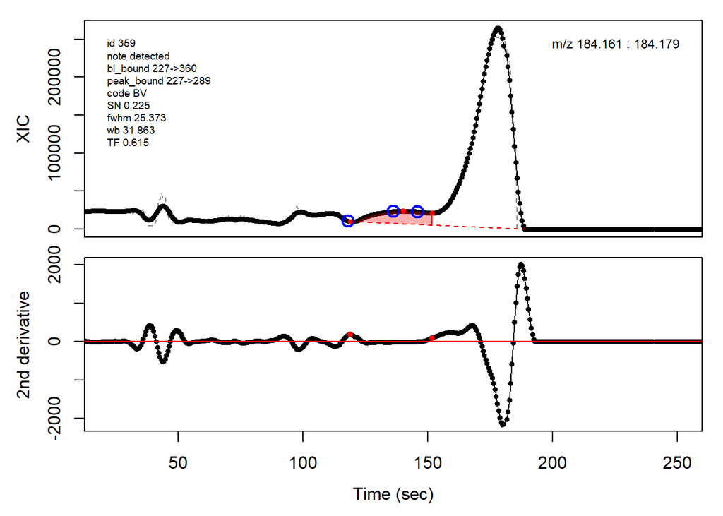

```
#> Opening file: C:\Users\kripi733\AppData\Local\Temp\RtmpusE9Et\temp_libpath39001f3d545d\cpc\extdata\hilic021.mzML
```

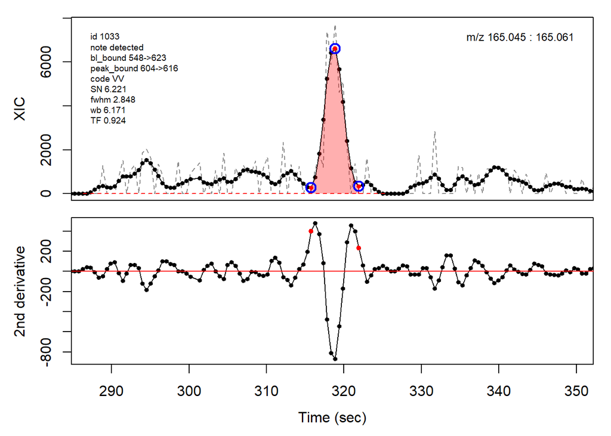

```r
cpc::plotPeaks(cpc, peakIdx = randomRemoved[[2]])
```

```
#> Opening file: C:\Users\kripi733\AppData\Local\Temp\RtmpusE9Et\temp_libpath39001f3d545d\cpc\extdata\hilic015.mzML
```

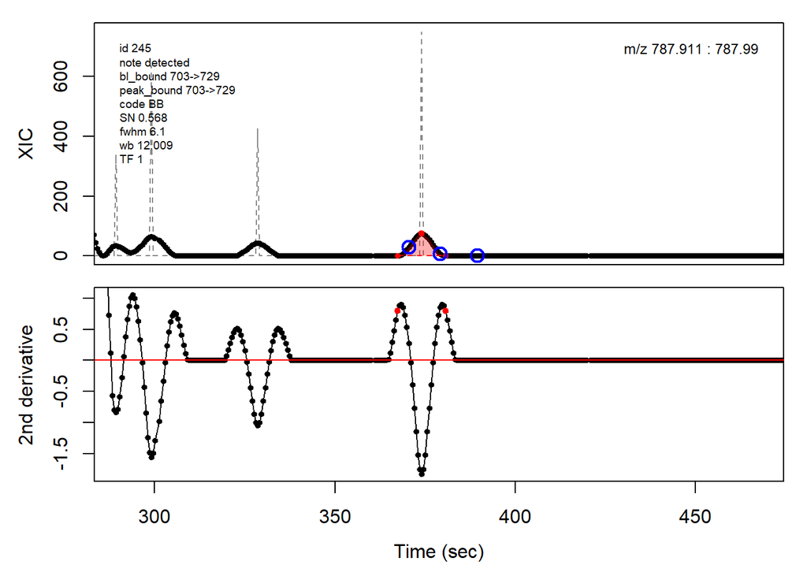

```r
cpc::plotPeaks(cpc, peakIdx = randomRemoved[[3]])
```

```
#> Opening file: C:\Users\kripi733\AppData\Local\Temp\RtmpusE9Et\temp_libpath39001f3d545d\cpc\extdata\hilic017.mzML
```

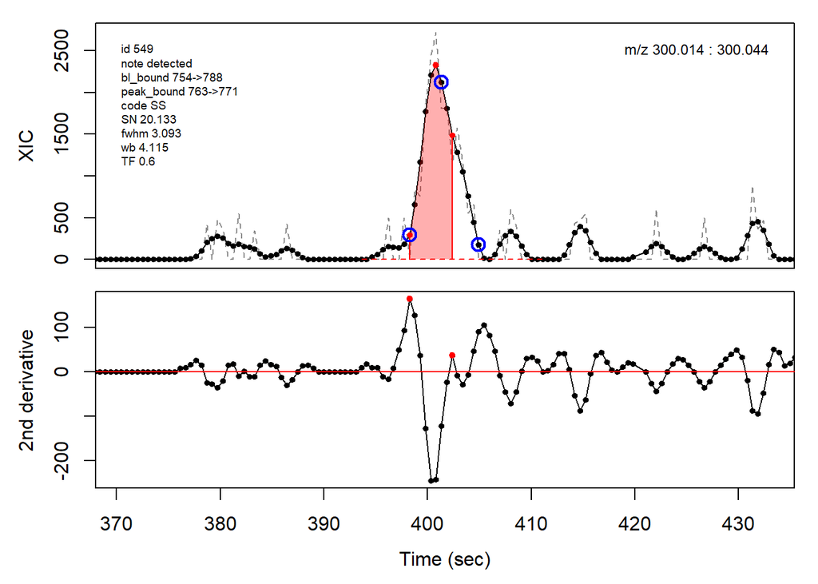

```
#> Opening file: C:\Users\kripi733\AppData\Local\Temp\RtmpusE9Et\temp_libpath39001f3d545d\cpc\extdata\hilic021.mzML
```

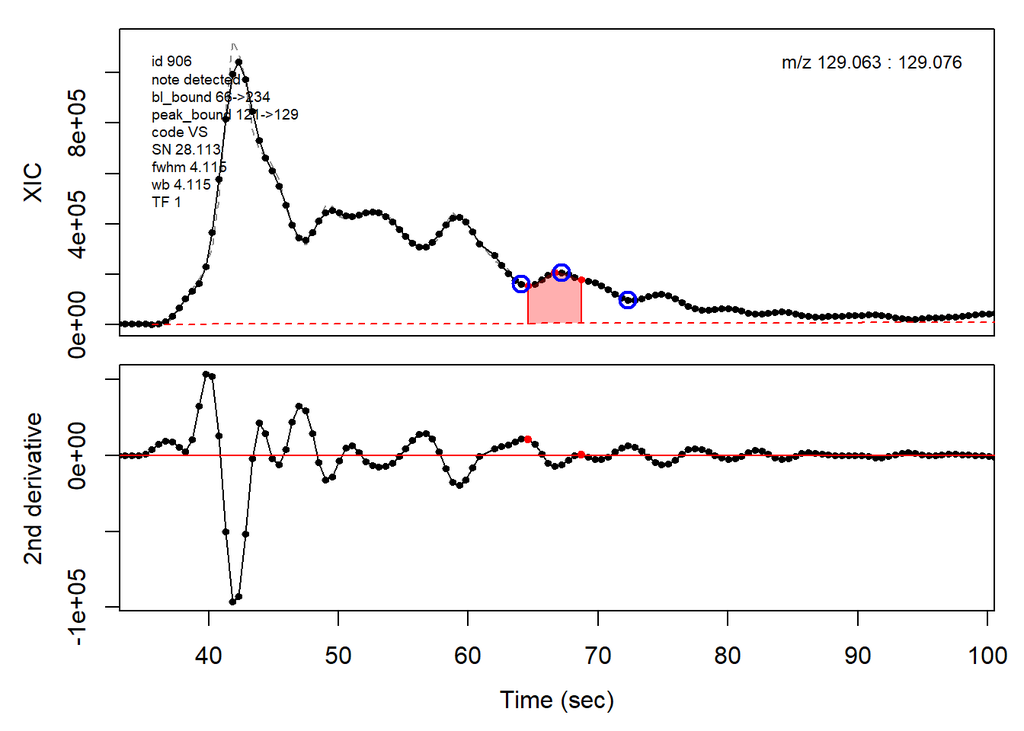

```r
cpc::plotPeaks(cpc, peakIdx = randomRemoved[[4]])
```

In the above plots the original XIC trace is plotted as a gray dashed line with the smoothed chromatogram overlaid on top in black. The black dots are the actual scan points. The blue circles represent the front boundary, apex location, and tail boundary, as determined by XCMS. The red fill indicates the peak boundaries determined by CPC with the red dot representing the apex point. The red dashed line is the baseline of the peak, as estimated by CPC.

```r
# get a vector of all detected peaks
allRetainedPeaks <- cpc::getRetainedPeaks(cpc)
allRetainedPeakIdx <- match(allRetainedPeaks, row.names(cpcPeaktable))

# determine the quartile break points
quarts <- quantile(cpcPeaktable$sn[allRetainedPeakIdx])
quarts[1] <- 0 # set the first boundary to be 0

quarts
```

```
#>        0%       25%       50%       75%      100%
#>   0.00000  28.49219  64.91197 161.98079       Inf
```

```r
# randomly select peaks in each quartile
noPeakFromEachQuartile <- 2

# randomly select the specified number of peaks from each quartile
set.seed(seed); randomRetained <- list(
  low <- sample(allRetainedPeaks[
    cpcPeaktable$sn[allRetainedPeakIdx] >= quarts[1] &
      cpcPeaktable$sn[allRetainedPeakIdx] < quarts[2]
  ], noPeakFromEachQuartile, FALSE), # 0% <= SN < 25%
  lowmed <- sample(allRetainedPeaks[
    cpcPeaktable$sn[allRetainedPeakIdx] >= quarts[2] &
      cpcPeaktable$sn[allRetainedPeakIdx] < quarts[3]
  ], noPeakFromEachQuartile, FALSE), # 25% <= SN < 50%
  medhigh <- sample(allRetainedPeaks[
    cpcPeaktable$sn[allRetainedPeakIdx] >= quarts[3] &
      cpcPeaktable$sn[allRetainedPeakIdx] < quarts[4]
  ], noPeakFromEachQuartile, FALSE), # 50% <= SN < 75%
  high <- sample(allRetainedPeaks[
    cpcPeaktable$sn[allRetainedPeakIdx] >= quarts[4] &
      cpcPeaktable$sn[allRetainedPeakIdx] < quarts[5]
  ], noPeakFromEachQuartile, FALSE)) # 75% <= SN < 100%

randomRetained
```

```
#> [[1]]
#> [1] "CP0644" "CP0246"
#>
#> [[2]]
#> [1] "CP1018" "CP1072"
#>
#> [[3]]
#> [1] "CP1048" "CP0709"
#>
#> [[4]]
#> [1] "CP0253" "CP0470"
```

And then we can plot all these peaks in the same way as with the removed peaks.

```
#> Opening file: C:\Users\kripi733\AppData\Local\Temp\RtmpusE9Et\temp_libpath39001f3d545d\cpc\extdata\hilic015.mzML
```

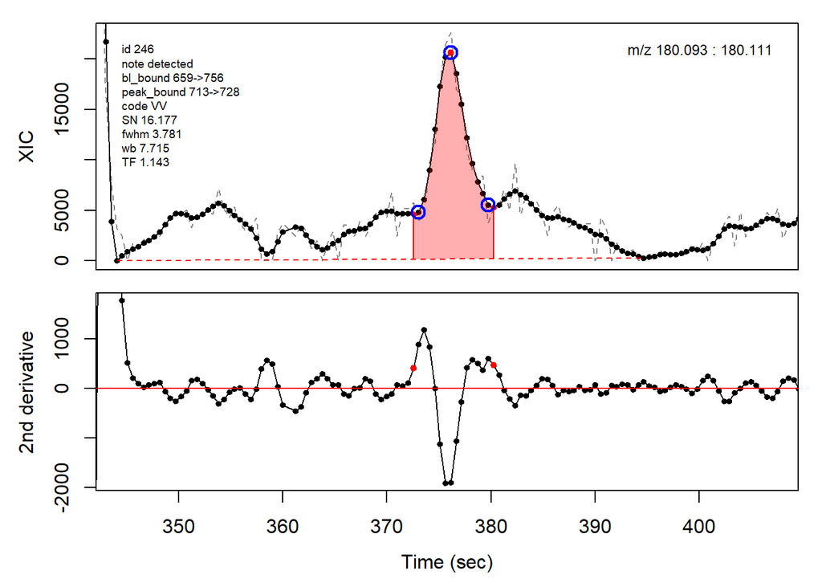

```
#> Opening file: C:\Users\kripi733\AppData\Local\Temp\RtmpusE9Et\temp_libpath39001f3d545d\cpc\extdata\hilic019.mzML
```

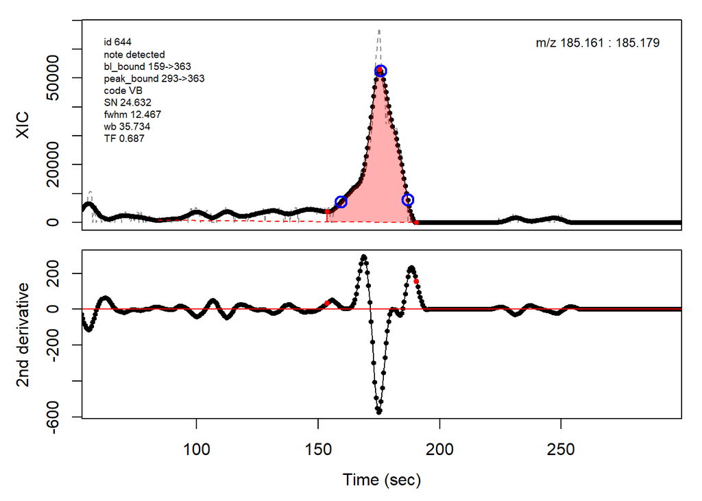

```r
cpc::plotPeaks(cpc, peakIdx = randomRetained[[1]])
```

```
#> Opening file: C:\Users\kripi733\AppData\Local\Temp\RtmpusE9Et\temp_libpath39001f3d545d\cpc\extdata\hilic021.mzML
```

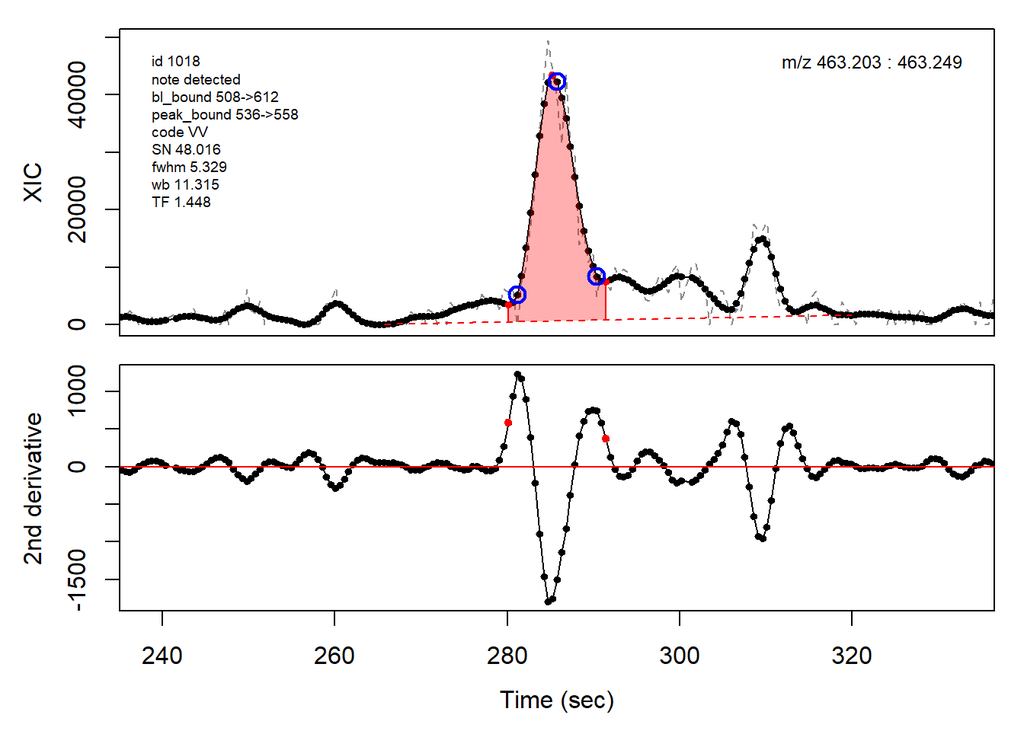

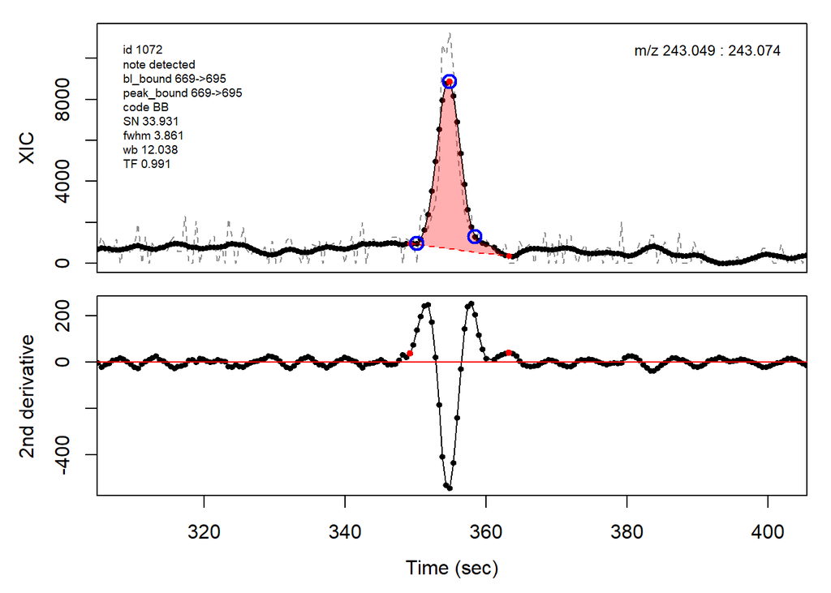

```r
cpc::plotPeaks(cpc, peakIdx = randomRetained[[2]])
```

```
#> Opening file: C:\Users\kripi733\AppData\Local\Temp\RtmpusE9Et\temp_libpath39001f3d545d\cpc\extdata\hilic019.mzML
```

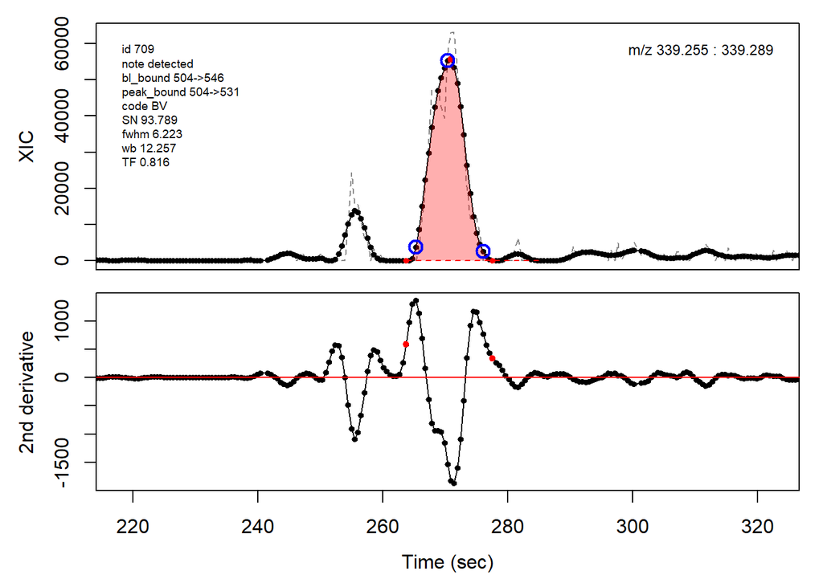

```
#> Opening file: C:\Users\kripi733\AppData\Local\Temp\RtmpusE9Et\temp_libpath39001f3d545d\cpc\extdata\hilic021.mzML
```

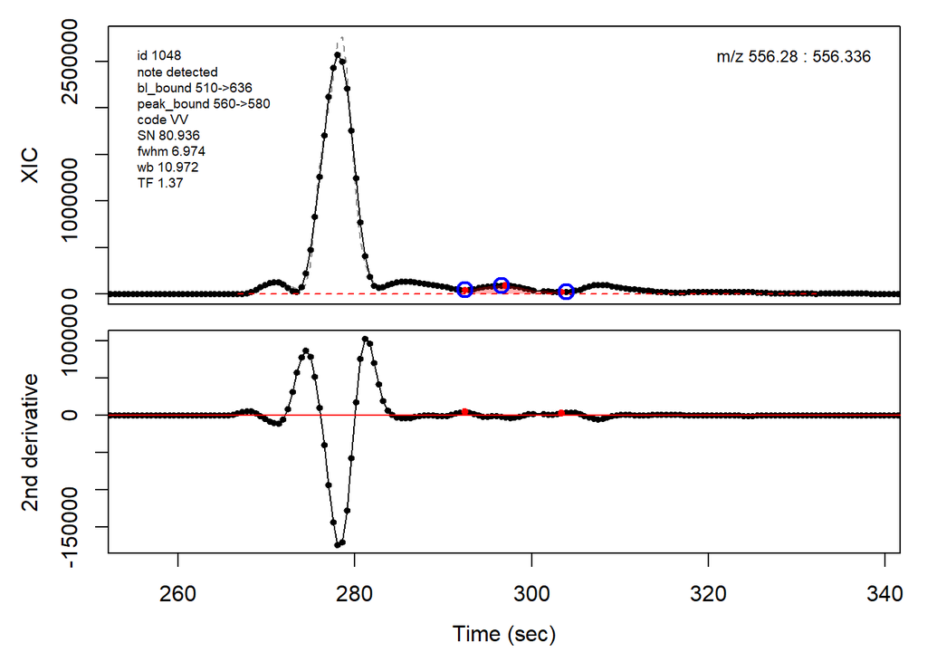

```r
cpc::plotPeaks(cpc, peakIdx = randomRetained[[3]])
```

```
#> Opening file: C:\Users\kripi733\AppData\Local\Temp\RtmpusE9Et\temp_libpath39001f3d545d\cpc\extdata\hilic015.mzML
```

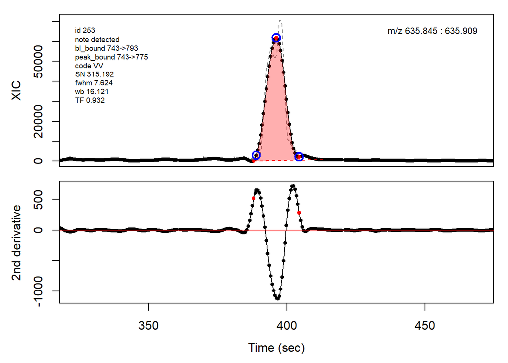

```
#> Opening file: C:\Users\kripi733\AppData\Local\Temp\RtmpusE9Et\temp_libpath39001f3d545d\cpc\extdata\hilic017.mzML
```

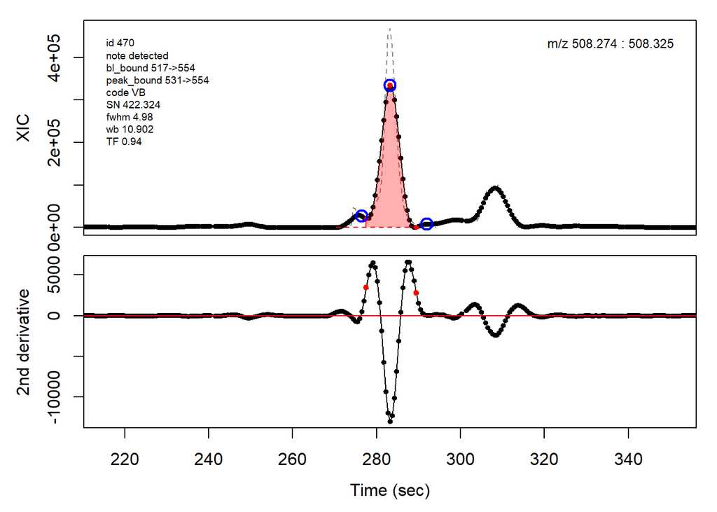

```r
cpc::plotPeaks(cpc, peakIdx = randomRetained[[4]])
```

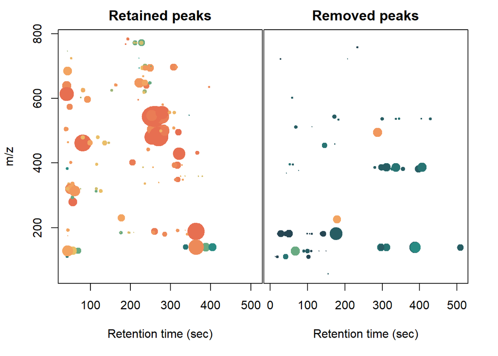

```r
# get a vector of all removed peak numeric IDs
removedPeaksIdx <- match(cpc::getRemovedPeaks(cpc), row.names(cpcPeaktable))

snVals <- cpcPeaktable$sn
snVals[which(snVals == Inf)] <- max(snVals[which(snVals != Inf)])*2
quanBreaks <- quantile(snVals, probs = seq(0,1,length.out = 17))
quanBreaks[1] <- 0

colPalette <- colorRampPalette(colors = c("#264653", "#2A9D8F", "#E9C46A",
                                          "#F4A261", "#E76F51"))(16)

colVec <- colPalette[as.integer(sapply(snVals, FUN = function(x) {
  which(quanBreaks[1:(length(quanBreaks)-1)] < x &
          quanBreaks[2:length(quanBreaks)] >= x)
}))]

# m/z ~ rt (xcms data) with separate panels for retained and removed peaks
layout(mat = matrix(c(1,2), nrow = 1), widths = c(0.53,0.47))
par(mar = c(5.1,4.1,2.1,0.1))
plot(x = xcmsPeaktableOrig$rt[-removedPeaksIdx],
     y = xcmsPeaktableOrig$mz[-removedPeaksIdx], pch = 20,
     col = colVec[-removedPeaksIdx],
     cex = log(pmax(0, xcmsPeaktableOrig$into[-removedPeaksIdx]) /
                 median(pmax(0, xcmsPeaktableOrig$into[-removedPeaksIdx]))),
     xlab = "Retention time (sec)", ylab = "m/z", main = "Retained peaks")

par(mar = c(5.1,0,2.1,2.1))
plot(x = xcmsPeaktableOrig$rt[removedPeaksIdx],
     y = xcmsPeaktableOrig$mz[removedPeaksIdx], pch = 20,
     col = colVec[removedPeaksIdx],
     cex = log(pmax(0, xcmsPeaktableOrig$into[removedPeaksIdx]) /
                 median(pmax(0, xcmsPeaktableOrig$into[removedPeaksIdx]))),
     xlab = "Retention time (sec)", yaxt = "n", ylab = "", main = "Removed peaks")
```

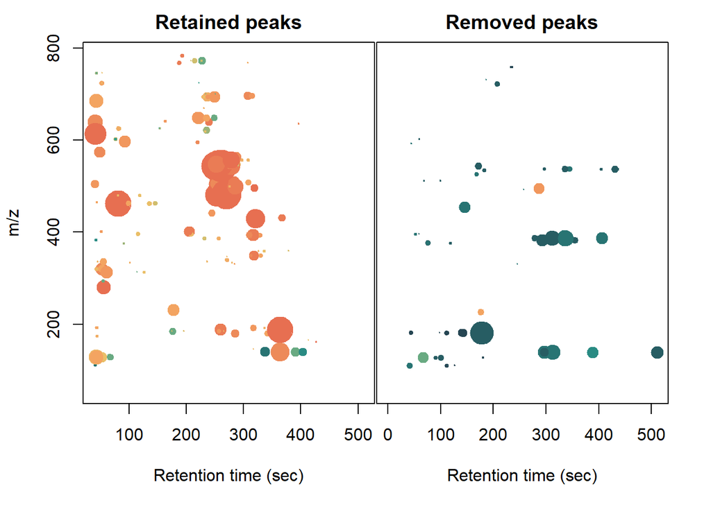

```r
# m/z ~ rt (cpc data) with separate panels for retained and removed peaks
layout(mat = matrix(c(1,2), nrow = 1), widths = c(0.53,0.47))
par(mar = c(5.1,4.1,2.1,0.1))
plot(x = cpcPeaktable$rt[-removedPeaksIdx],
     y = xcmsPeaktableOrig$mz[-removedPeaksIdx], pch = 20,
     col = colVec[-removedPeaksIdx],
     cex = log(pmax(0, cpcPeaktable$area[-removedPeaksIdx]) /
                 median(pmax(0, cpcPeaktable$area[-removedPeaksIdx]))),
     xlab = "Retention time (sec)", ylab = "m/z", main = "Retained peaks")

par(mar = c(5.1,0,2.1,2.1))
plot(x = cpcPeaktable$rt[removedPeaksIdx],
     y = xcmsPeaktableOrig$mz[removedPeaksIdx], pch = 20,
     col = colVec[removedPeaksIdx],
     cex = log(pmax(0, cpcPeaktable$area[removedPeaksIdx]) /
                 median(pmax(0, cpcPeaktable$area[removedPeaksIdx]))),
     xlab = "Retention time (sec)", yaxt = "n", ylab = "", main = "Removed peaks")
```

# Peak cluster boundaries

Overlapping peak clusters can be detected by the algorithm as their baseline boundaries after expansion will overlap. Consequently the boundaries between peaks in clusters need to be determined and updated. This is handled differently depending on the degree of overlap. Valley boundaries between peaks are set to the lowest point between the peak apices along the ion trace. Shoulder boundaries are set to the maxima between the peak apices along the second derivative of the ion trace. When two similarily sized peaks overlap sufficiently much, it can lead to a rounded peak shape. This is detected as two peak apices that share inflection points along the second derivative which a negative valued maxima in between the apice points. The boundary is then set to the negative maxima point between the apices.

```
#> Opening file: C:\Users\kripi733\AppData\Local\Temp\RtmpusE9Et\temp_libpath39001f3d545d\cpc\extdata\hilic021.mzML
```

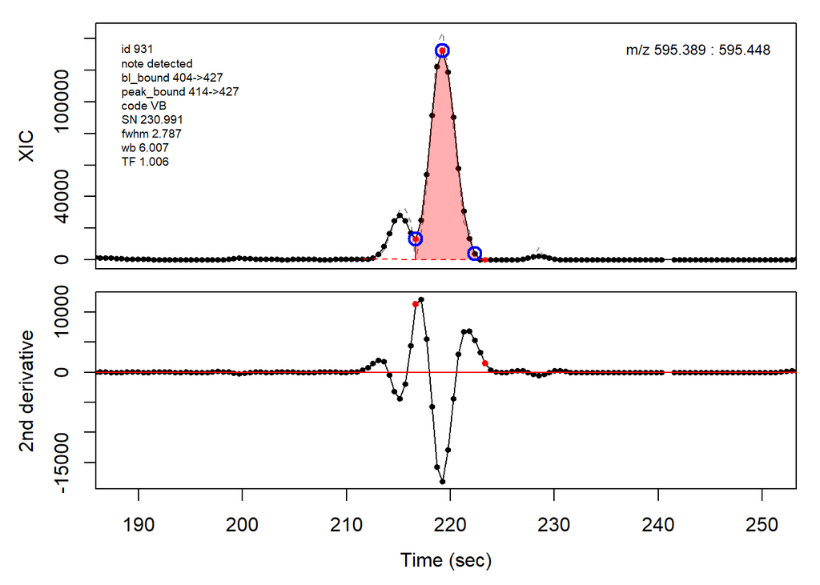

```r
# Valley boundary example
cpc::plotPeaks(cpc, 931)
```

```
#> Opening file: C:\Users\kripi733\AppData\Local\Temp\RtmpusE9Et\temp_libpath39001f3d545d\cpc\extdata\hilic017.mzML
```

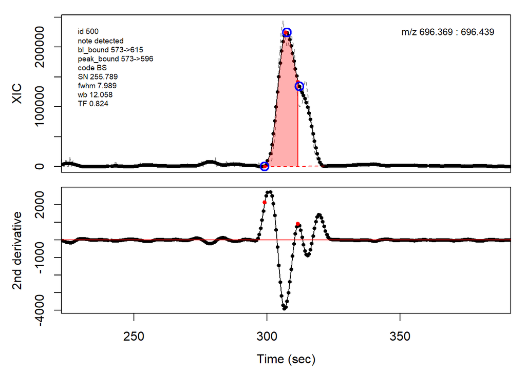

```r
# Shoulder boundary example
cpc::plotPeaks(cpc, 500)
```

# Example of EMG deconvolution

The processing engine used in the CPC package includes EMG deconvolution of peak clusters to achieve better estimates of the peak boundaries. This can be included in the processing by setting the argument *fit_emg = TRUE* in the *cpcProcParam* object.

To illustrate this, we first need to find a few peaks to perform EMG deconvolution on.

```r
(selection <- c(34, 138, 106, 165, 179, 217))
```

```
#> [1]  34 138 106 165 179 217
```

```r
(peakIdx <- row.names(cpcPeaktable[selection, ]))
```

```
#> [1] "CP0034" "CP0138" "CP0106" "CP0165" "CP0179" "CP0217"
```

```r
(selection <- cpcPeaktable$id[selection])
```

```
#> [1]  34 138 106 165 179 217
```

```
#> Opening file: C:\Users\kripi733\AppData\Local\Temp\RtmpusE9Et\temp_libpath39001f3d545d\cpc\extdata\hilic015.mzML
```

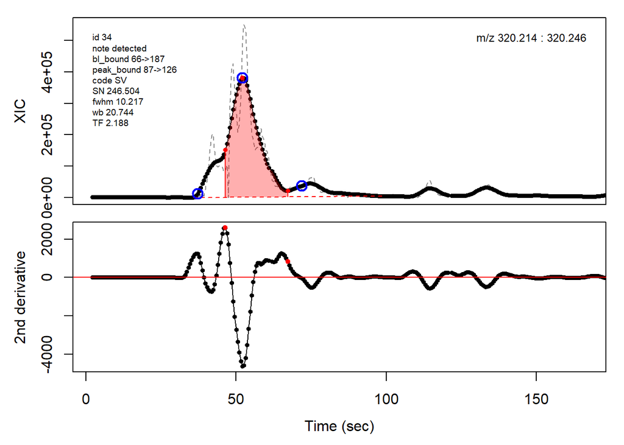

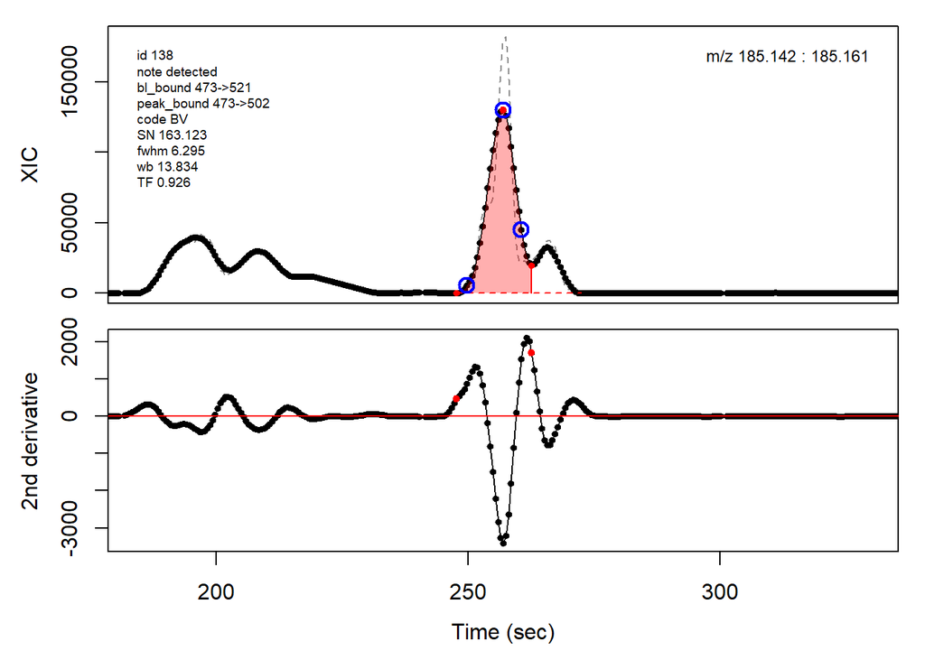

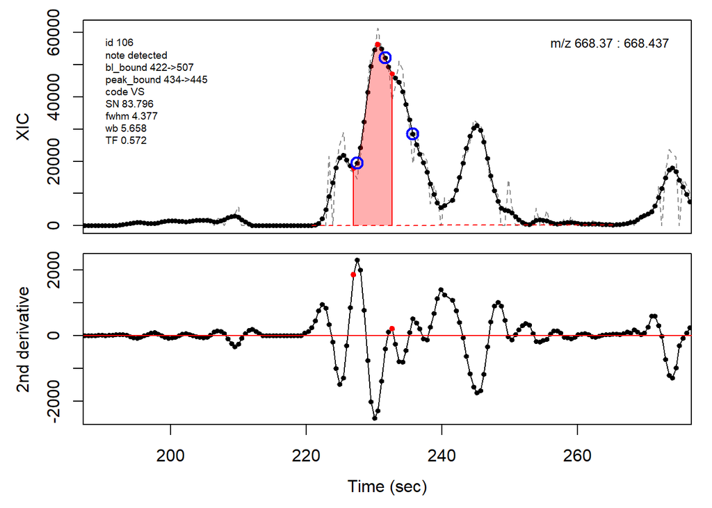

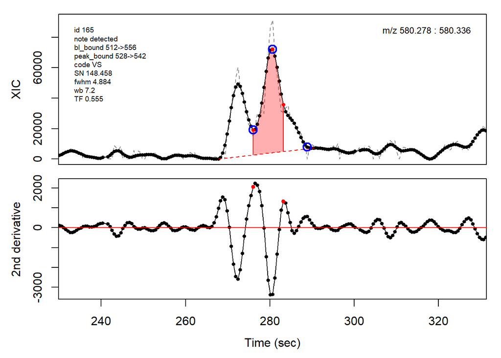

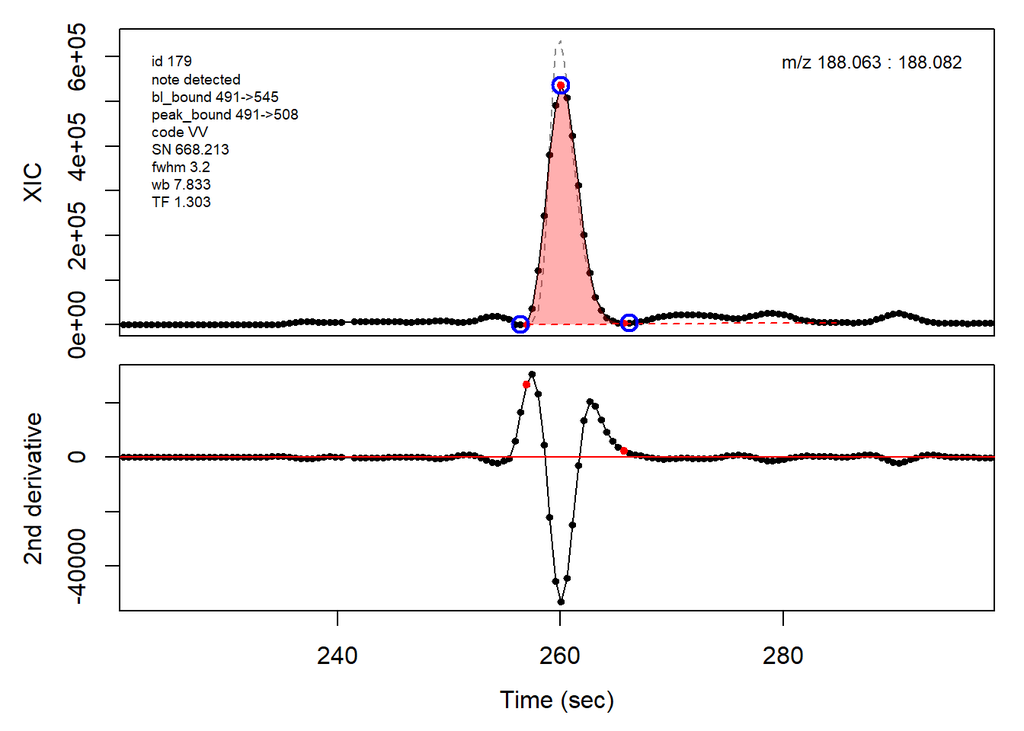

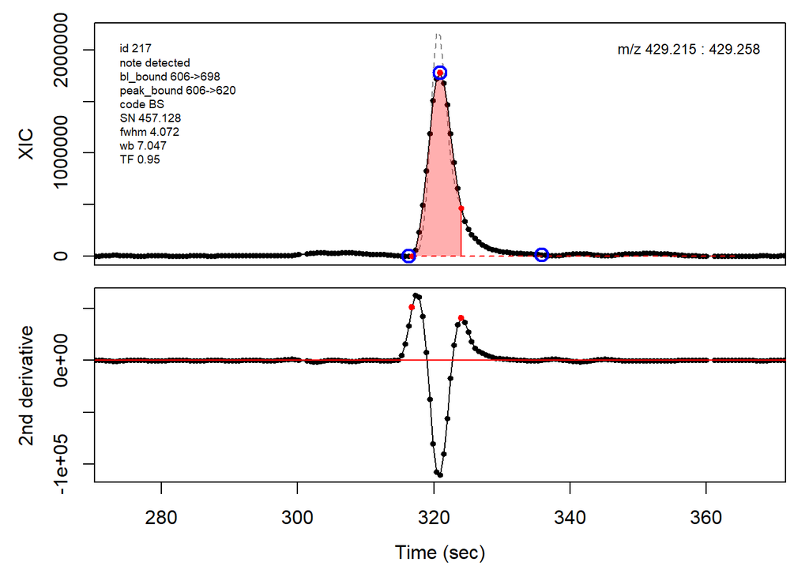

```r
cpc::plotPeaks(cpc, peakIdx = selection)
```

```r
cpcParam <- cpc::cpcProcParam(fit_emg = TRUE, sel_peaks = selection, plot = F,
                              save_all = TRUE)
cpcDeconv <- cpc::characterize_xcms_peaklist(xd = xd, param = cpcParam)
```

```
#> Processing file: C:\Users\kripi733\AppData\Local\Temp\RtmpusE9Et\temp_libpath39001f3d545d\cpc\extdata\hilic015.mzML
#> Found 6 peak(s).
#> % complete:
#> 10
#> 30
#> 50
#> 60
#> 80
#> 100
#> Done!
#> Finished in 0.996 secs.
```

```
#> Opening file: C:\Users\kripi733\AppData\Local\Temp\RtmpusE9Et\temp_libpath39001f3d545d\cpc\extdata\hilic015.mzML
```

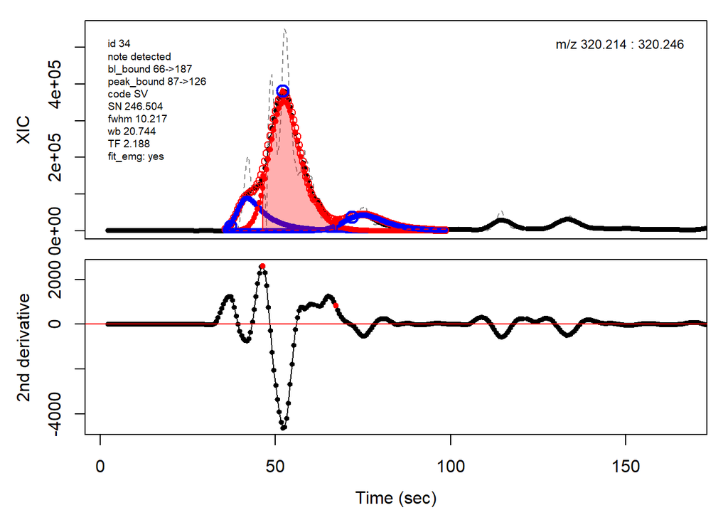

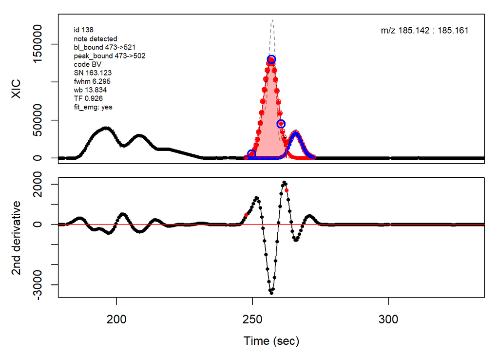

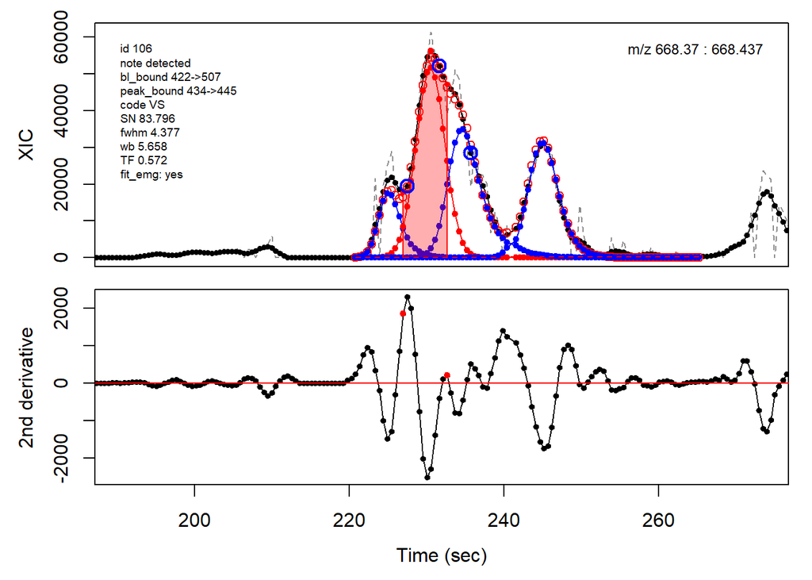

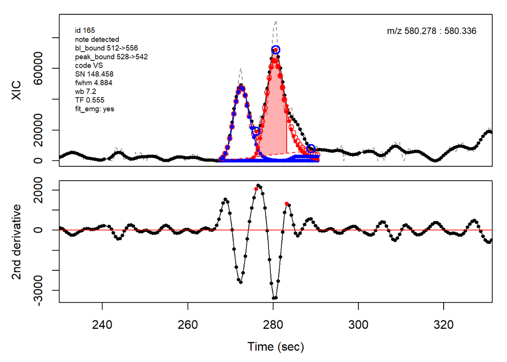

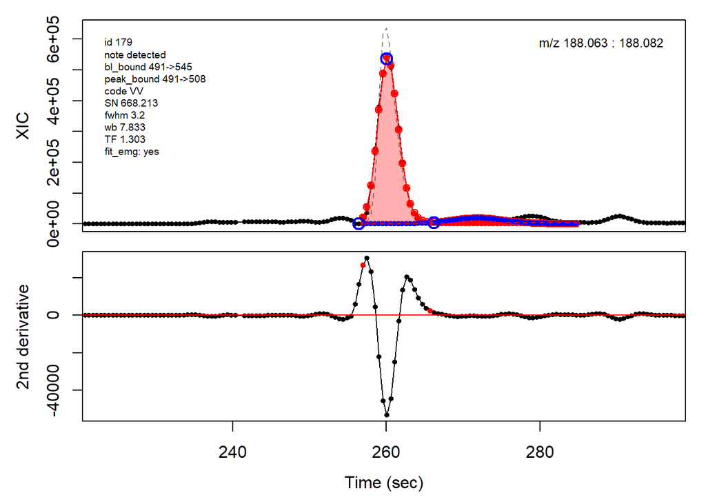

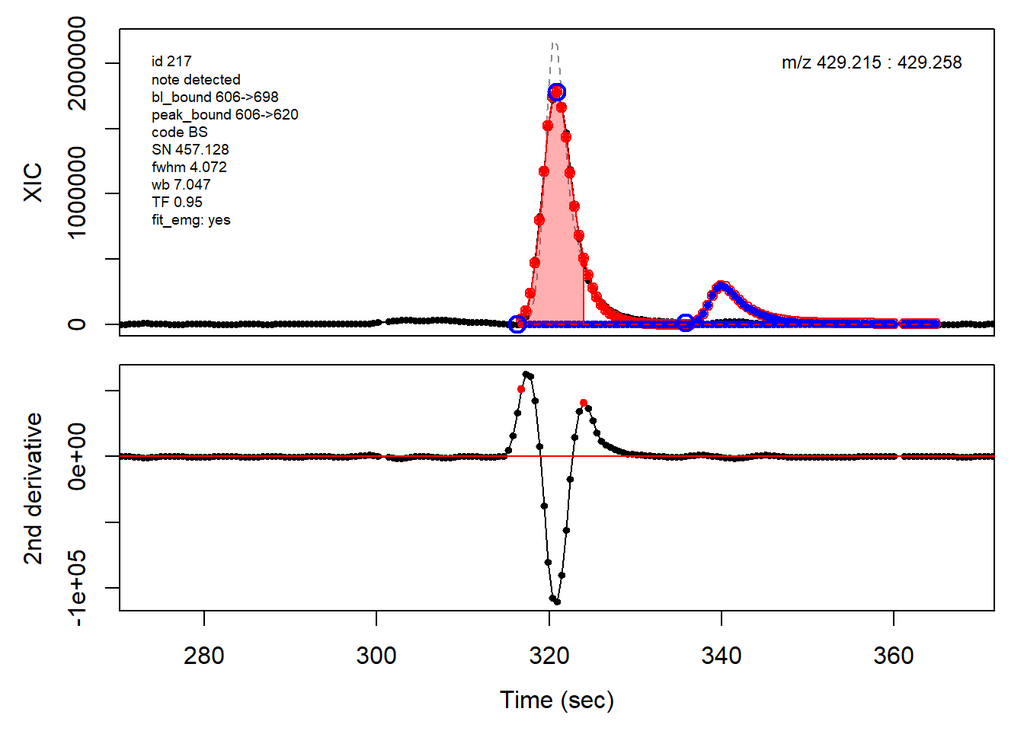

```r
cpc::plotPeaks(cpc = cpcDeconv, peakIdx = peakIdx, plotEMG = T)
```